# Applied Exercises for Chapter 2

Jean Cochrane

8 July 2018

### Exercise 8

1. First, let’s read the `college.csv` data into R:

```r
college = read.csv('data/college.csv')
```

2. Next, we can change the rownames so that the rows are labelled with the college name but that name is not considered part of the data:

```r
# Label each row with the name of the college
rownames(college) = college[,1]

# Remove the name of the college (column 1) from the data
college = college[,-1]
```

c.i. Numerical summary of the dataset:

```r
summary(college)
```

```
##  Private        Apps           Accept          Enroll       Top10perc
##  No :212   Min.   :   81   Min.   :   72   Min.   :  35   Min.   : 1.00
##  Yes:565   1st Qu.:  776   1st Qu.:  604   1st Qu.: 242   1st Qu.:15.00
##            Median : 1558   Median : 1110   Median : 434   Median :23.00
##            Mean   : 3002   Mean   : 2019   Mean   : 780   Mean   :27.56
##            3rd Qu.: 3624   3rd Qu.: 2424   3rd Qu.: 902   3rd Qu.:35.00
##            Max.   :48094   Max.   :26330   Max.   :6392   Max.   :96.00
##    Top25perc      F.Undergrad     P.Undergrad         Outstate
##  Min.   :  9.0   Min.   :  139   Min.   :    1.0   Min.   : 2340
##  1st Qu.: 41.0   1st Qu.:  992   1st Qu.:   95.0   1st Qu.: 7320
##  Median : 54.0   Median : 1707   Median :  353.0   Median : 9990
##  Mean   : 55.8   Mean   : 3700   Mean   :  855.3   Mean   :10441
##  3rd Qu.: 69.0   3rd Qu.: 4005   3rd Qu.:  967.0   3rd Qu.:12925
##  Max.   :100.0   Max.   :31643   Max.   :21836.0   Max.   :21700
##    Room.Board       Books           Personal         PhD
##  Min.   :1780   Min.   :  96.0   Min.   : 250   Min.   :  8.00
##  1st Qu.:3597   1st Qu.: 470.0   1st Qu.: 850   1st Qu.: 62.00
##  Median :4200   Median : 500.0   Median :1200   Median : 75.00
##  Mean   :4358   Mean   : 549.4   Mean   :1341   Mean   : 72.66
##  3rd Qu.:5050   3rd Qu.: 600.0   3rd Qu.:1700   3rd Qu.: 85.00
##  Max.   :8124   Max.   :2340.0   Max.   :6800   Max.   :103.00
##     Terminal       S.F.Ratio      perc.alumni        Expend
##  Min.   : 24.0   Min.   : 2.50   Min.   : 0.00   Min.   : 3186
##  1st Qu.: 71.0   1st Qu.:11.50   1st Qu.:13.00   1st Qu.: 6751
##  Median : 82.0   Median :13.60   Median :21.00   Median : 8377
##  Mean   : 79.7   Mean   :14.09   Mean   :22.74   Mean   : 9660
##  3rd Qu.: 92.0   3rd Qu.:16.50   3rd Qu.:31.00   3rd Qu.:10830
##  Max.   :100.0   Max.   :39.80   Max.   :64.00   Max.   :56233
##    Grad.Rate
##  Min.   : 10.00
##  1st Qu.: 53.00
##  Median : 65.00
##  Mean   : 65.46
##  3rd Qu.: 78.00
##  Max.   :118.00
```

c.ii. A scatterplot matrix of the first ten columns of the data:

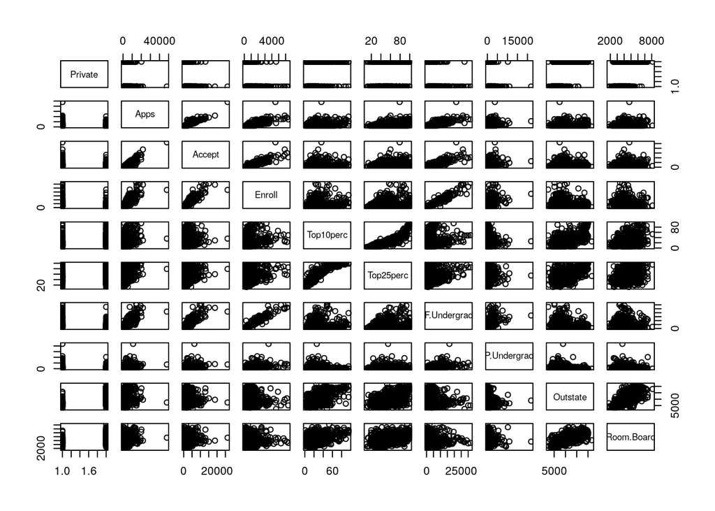

```r
pairs(college[,1:10])
```

c.iii. A boxplot of `Outstate` vs. `Private`:

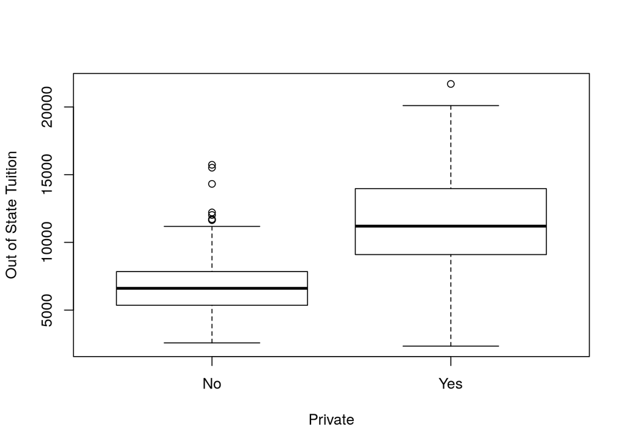

```r
outstate = college$Outstate
private = as.factor(college$Private)

plot(private, outstate, xlab="Private", ylab="Out of State Tuition")
```

c.iv. Create a new qualitative variable, `Elite`, by binning `Top10perc`:

```r
Elite = rep("No", nrow(college))
Elite[college$Top10perc > 50] = "Yes"
Elite = as.factor(Elite)

college = data.frame(college, Elite)
summary(college$Elite)
```

```
##  No Yes
## 699  78
```

So there are 78 “elite” universities in this dataset.

Side-by-side boxplots of `Outstate` versus `Elite`:

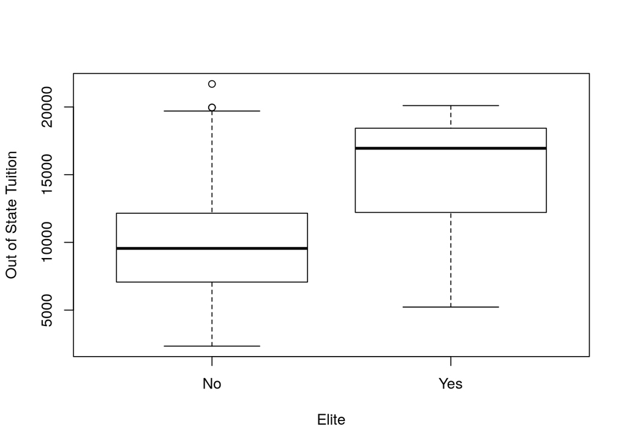

```r
plot(Elite, outstate, xlab="Elite", ylab="Out of State Tuition")
```

c.v. Histograms of some of the quantitative variables:

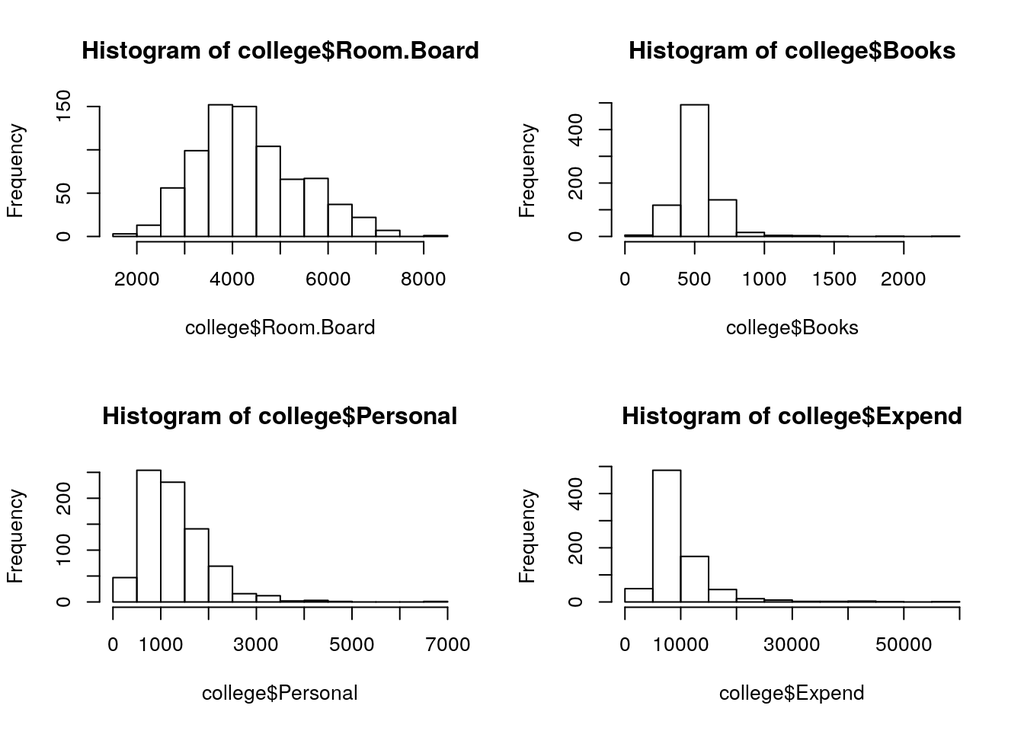

```r
par(mfrow=c(2,2))
hist(college$Room.Board, plot=TRUE)
hist(college$Books, plot=TRUE)
hist(college$Personal, plot=TRUE)
hist(college$Expend, plot=TRUE)
```

### Exercise 9

Load in the `auto` dataset from a CSV:

```r
auto = na.omit(read.csv('data/auto.csv', header=TRUE))
```

1. To determine which predictors are quantitative vs. qualitative, let’s first take a look at a summary of the data:

```r
summary(auto)
```

```
##       mpg          cylinders      displacement     horsepower
##  Min.   : 9.00   Min.   :3.000   Min.   : 68.0   150    : 22
##  1st Qu.:17.50   1st Qu.:4.000   1st Qu.:104.0   90     : 20
##  Median :23.00   Median :4.000   Median :146.0   88     : 19
##  Mean   :23.52   Mean   :5.458   Mean   :193.5   110    : 18
##  3rd Qu.:29.00   3rd Qu.:8.000   3rd Qu.:262.0   100    : 17
##  Max.   :46.60   Max.   :8.000   Max.   :455.0   75     : 14
##                                                  (Other):287
##      weight      acceleration        year           origin
##  Min.   :1613   Min.   : 8.00   Min.   :70.00   Min.   :1.000
##  1st Qu.:2223   1st Qu.:13.80   1st Qu.:73.00   1st Qu.:1.000
##  Median :2800   Median :15.50   Median :76.00   Median :1.000
##  Mean   :2970   Mean   :15.56   Mean   :75.99   Mean   :1.574
##  3rd Qu.:3609   3rd Qu.:17.10   3rd Qu.:79.00   3rd Qu.:2.000
##  Max.   :5140   Max.   :24.80   Max.   :82.00   Max.   :3.000
##
##              name
##  ford pinto    :  6
##  amc matador   :  5
##  ford maverick :  5
##  toyota corolla:  5
##  amc gremlin   :  4
##  amc hornet    :  4
##  (Other)       :368
```

Based on this table, we can make the following categorizations:

- **Quantitative**:
  - `mpg`
  - `displacement`
  - `weight`
  - `acceleration`
- **Qualitative**:
  - `cylinders`
  - `year`
  - `horsepower`
  - `name`
  - `origin`

Three of the qualitative variables are tricky: while `cylinders,`year`, and`horsepower` are all expressed in terms of integers, they are in fact qualitative, since they represent distinct bins and are not continuous. (It wouldn’t make sense to try to predict e.g. mpg for a car with 3.36 cylinders, for example.)

2. The ranges of the quantitative variables include:

```r
range(auto$mpg)
```

```
## [1]  9.0 46.6
```

```r
range(auto$displacement)
```

```
## [1]  68 455
```

```r
range(auto$weight)
```

```
## [1] 1613 5140
```

```r
range(auto$acceleration)
```

```
## [1]  8.0 24.8
```

3. The means of the quantiative variables are reported in the `summary` table above. To find the standard deviation of each predictor, we can use the built-in `sd` function:

```r
sd(auto$mpg)
```

```
## [1] 7.825804
```

```r
sd(auto$displacement)
```

```
## [1] 104.3796
```

```r
sd(auto$weight)
```

```
## [1] 847.9041
```

```r
sd(auto$acceleration)
```

```
## [1] 2.749995
```

This gives us the following table:

| predictor | mean | standard deviation |
| --- | --- | --- |
| `mpg` | 23.52 | 7.83 |
| `displacement` | 193.5 | 104.38 |
| `weight` | 2970 | 847.90 |
| `acceleration` | 15.56 | 2.75 |

4. Slice the data to remove the 10th through 85th samples:

```r
autoSlice = auto[-10:-85,]
```

It’s annoying to have to run the `sd` method separately from `summary`, so let’s write a quick function to add standard deviations into our summaries:

```r
summaryWithStd = function(vec) {
    summ = summary(vec)
    stdev = signif(sd(vec), digits=3)
    return(c(summ['Min.'], summ['Max.'], summ['Mean'], 'StdDev'=stdev))
}
```

Finally, get summaries including the range, mean, and standard deviation for each quantitative variable:

```r
summaryWithStd(autoSlice$mpg)
```

```
##     Min.     Max.     Mean   StdDev
## 11.00000 46.60000 24.43863  7.91000
```

```r
summaryWithStd(autoSlice$displacement)
```

```
##     Min.     Max.     Mean   StdDev
##  68.0000 455.0000 187.0498  99.6000
```

```r
summaryWithStd(autoSlice$weight)
```

```
##     Min.     Max.     Mean   StdDev
## 1649.000 4997.000 2933.963  811.000
```

```r
summaryWithStd(autoSlice$acceleration)
```

```
##     Min.     Max.     Mean   StdDev
##  8.50000 24.80000 15.72305  2.68000
```

6. In order to determine which other variables might be predictive of `mpg`, let’s look at some plots:

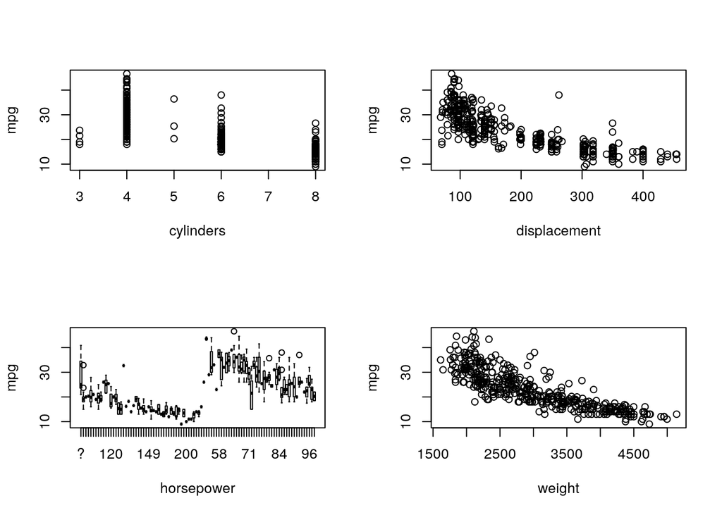

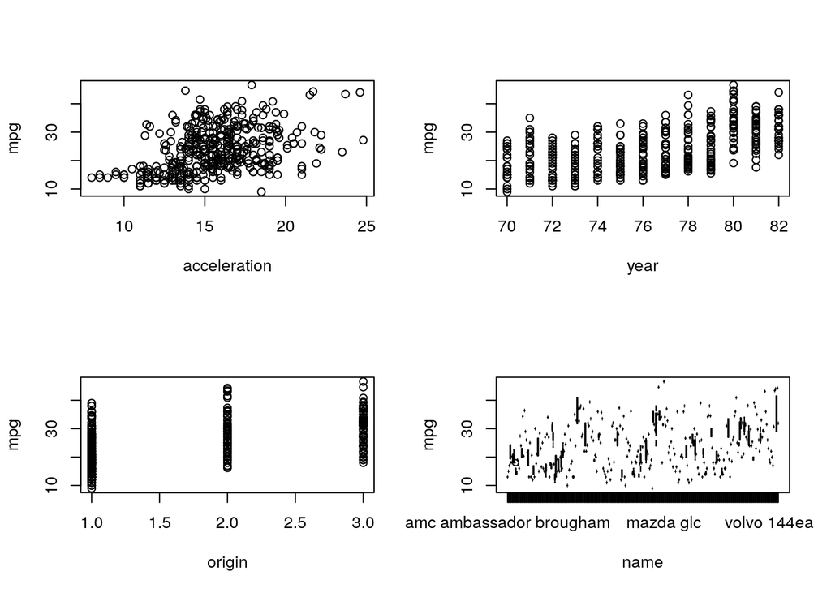

```r
par(mfrow=c(2,2))

# Remove the `mpg` column
colnamesNoMpg = colnames(auto[,!(colnames(auto) %in% c('mpg'))])

# Make plots for each column
for (col in colnamesNoMpg) {
    plot(auto[,col], auto$mpg, xlab=col, ylab='mpg')
}
```

I would consider these variables to be good candidates for predicting `mpg`.

### Exercise 10

1. Load the Boston housing data set:

```r
library(MASS)
```

Find the number of rows and columns:

```r
dim(Boston)
```

```
## [1] 506  14
```

Each row represents a town in the suburb of Boston, and each column is a particular measurement of that town.

5. To find the number of suburbs that bound the Charles river:

```r
dim(Boston[Boston$chas == 1,])[1]
```

```
## [1] 35
```

6. Median pupil-teacher ratio for towns in the dataset:

```r
median(Boston$ptratio)
```

```
## [1] 19.05
```

7. Two suburbs are tied for the lowest median value of owner-occupied homes:

```r
Boston[Boston$medv == min(Boston$medv),]
```

```
##        crim zn indus chas   nox    rm age    dis rad tax ptratio  black
## 399 38.3518  0  18.1    0 0.693 5.453 100 1.4896  24 666    20.2 396.90
## 406 67.9208  0  18.1    0 0.693 5.683 100 1.4254  24 666    20.2 384.97
##     lstat medv
## 399 30.59    5
## 406 22.98    5
```

Few surprises here: for variables that we might assume would predict lower house prices, the predictors for these towns are all in the upper quartile (if not the max itself). One predictor surprised me, however: the weighted mean of distances to employment centers (`dis`), which at 1.49 and 1.43 is in the lower end of the distribution across the dataset:

```r
summary(Boston$dis)
```

```
##    Min. 1st Qu.  Median    Mean 3rd Qu.    Max.
##   1.130   2.100   3.207   3.795   5.188  12.127
```

A few different possibilities:

1. I’m misinterpreting this variable and lower values actually indicates *further* distances from employment centers
2. The effect of distance on house price is not what I would have guesssed (i.e. further distances from employment centers predicts higher house prices)
3. Something is unusual about these two neighborhoods, and they don’t fit the usual trend of `dis` predicting `medv`

We can at least adjudicate between hypotheses 2 and 3 above by making a quick plot of the relationship between `dis` and `medv`:

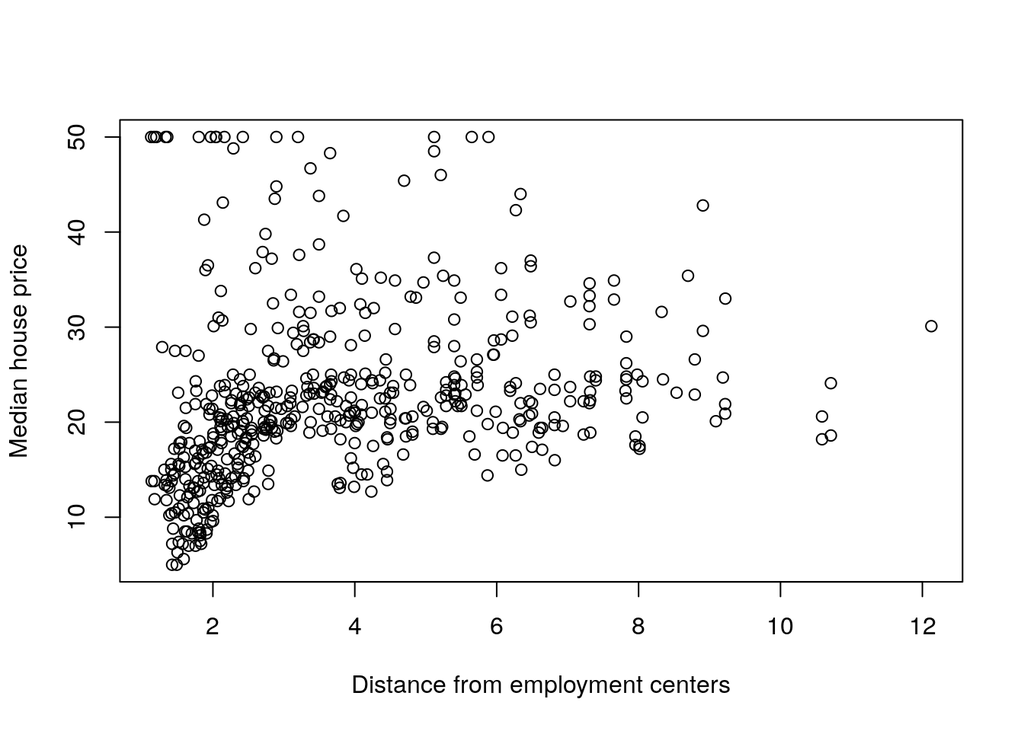

```r
plot(Boston$dis, Boston$medv, xlab='Distance from employment centers',
     ylab='Median house price')
```

The distribution here is pretty unusual, and it’s hard to determine an effect just by looking at it. If anything I’d guess a logarithmic effect, with a prominent outlier cluster very close to employment centers (perhaps suburbs that are very close to the city center?) but we’ll have to wait for the regression chapters to explore that question in a more principled fashion.